# 303.2. Galaxy Shapes in DP1

For the Rubin Science Platform at data.lsst.cloud.  
Data Release: [Data Preview 1](https://dp1.lsst.io/)  
Container Size: Large  
LSST Science Pipelines version: r29.2.0  
Last verified to run: 2025-09-02  
Repository: github.com/lsst/tutorial-notebooks

**Learning objective:** Explore the available measurements of galaxy shapes produced by the LSST pipelines and their applications.

**LSST data products:** objectTable, deepCoadd

**Packages:** `lsst.afw`, `lsst.rsp`, `lsst.geom`, `lsst.gauss2d`, `astropy`, `photutils`, `galsim`

**Credit:** Originally developed by Christina Williams and the Rubin Community Science team. This notebook is partly based on DP0.2 notebook 18 on galaxy photometry, and benefitted from earlier exploration of simulated data and notebook development by Melissa Graham and Dan Taranu, and helpful discussions with Jim Bosch.

**Get Support:** Everyone is encouraged to ask questions or raise issues in the [Support Category](https://community.lsst.org/c/support) of the Rubin Community Forum. Rubin staff will respond to all questions posted there.

## 1. Introduction

The LSST Science Pipelines make a variety of automated shape and morphology measurements for extended sources that are useful for galaxy evolution science. This notebook will teach the user about these measurements. They are performed on the `deepCoadd` images and appear in the `objectTable` as part of the LSST pipelines data products. The focus will be on galaxies. Data products related to shapes for the purpose of cosmological will be demonstrated elsewhere.

This notebook partly is based on a DP0.2 notebook (18) about galaxy photometry. Please note that the `objectTable` columns and contents may have changed between DP0.2 and DP1.

### 1.1. Import packages

Import `numpy`, a fundamental package for scientific computing with arrays in Python (numpy.org), and `matplotlib`, a comprehensive library for data visualization ([matplotlib.org](https://matplotlib.org/); [matplotlib gallery](https://matplotlib.org/stable/gallery/index.html)).

From the `lsst` package, import modules for accessing the Table Access Protocol (TAP) service, and image display functions from the LSST Science Pipelines ([pipelines.lsst.io](https://pipelines.lsst.io/)). Also import some geometric functions to help plot photometric apertures.

From the `pyvo` package, import some functions that will enable using the image cutout tool. From `astropy` and `photutils` import packages to enable plotting images and drawing shapes on images with WCS information.

Finally, import `galsim` which is the galaxy simulation package, which was used to build the DP0.2 simulated images. This package and the lsst package `gauss2d` are useful for reconstructing the sersic profiles that are used to model the galaxies in Rubin images.

```python
import numpy as np
import matplotlib.pyplot as plt

import lsst.geom as geom

from lsst.rsp import get_tap_service
from lsst.rsp.utils import get_pyvo_auth
from lsst.rsp.service import get_siav2_service

import lsst.afw.display as afwDisplay
from lsst.afw.image import ExposureF
from lsst.afw.fits import MemFileManager
import lsst.afw.geom.ellipses as ellipses

from pyvo.dal.adhoc import DatalinkResults, SodaQuery

from astropy.wcs import WCS
from astropy.coordinates import SkyCoord
import astropy.units as u

from photutils.aperture import SkyEllipticalAperture

import galsim as gs
from lsst.gauss2d import Ellipse, EllipseMajor, Covariance
```

### 1.2. Define parameters and functions

Define a function to generate an image cutout, using the Rubin image cutout service. Further information about the cutout tool can be found in DP1 tutorial notebook 103.4 that demonstrates the Rubin image cutout service.

```python
def make_image_cutout(ra, dec, cutout_size=0.01, band='i'):
    """
    Wrapper function to generate a cutout using the cutout tool.
    Default is to show cutout in i-band.

    Parameters
    ----------
    ra, dec : 'float'
        the ra and dec of the cutout center
    cutout_size : 'float', optional
        radial edge length in degrees of the cutout

    Returns
    -------
    mem : 'object'
        An lsst.afw.fits._fits.MemFileManager object containing the
        cutout image bytes returned by the cutout tool. The
        cutout image bytes can be accessed as an LSST awf image
        exposure class format such as: cutout = ExposureF(mem)
    """
    service = get_siav2_service("dp1")
    spherePoint = geom.SpherePoint(ra*geom.degrees, dec*geom.degrees)

    circle = (ra, dec, cutout_size)
    results = service.search(pos=circle, calib_level=3)
    table = results.to_table()
    tx = np.where((table['dataproduct_subtype'] == 'lsst.deep_coadd')
                  & (table['lsst_band'] == band))[0]

    datalink_url = results[tx[0].item()].access_url
    dl = DatalinkResults.from_result_url(datalink_url, session=get_pyvo_auth())

    sq = SodaQuery.from_resource(dl,
                                 dl.get_adhocservice_by_id("cutout-sync"),
                                 session=get_pyvo_auth())

    sq.circle = (spherePoint.getRa().asDegrees() * u.deg,
                 spherePoint.getDec().asDegrees() * u.deg,
                 cutout_size * u.deg)
    cutout_bytes = sq.execute_stream().read()
    mem = MemFileManager(len(cutout_bytes))
    mem.setData(cutout_bytes, len(cutout_bytes))

    return mem
```

Define parameters to use colorblind-friendly colors with `matplotlib`.

```python
plt.style.use('seaborn-v0_8-colorblind')
prop_cycle = plt.rcParams['axes.prop_cycle']
colors = prop_cycle.by_key()['color']
```

Set the `afwDisplay` backend to `matplotlib` to enable use of various packages to overplot on images.

```python
afwDisplay.setDefaultBackend('matplotlib')
```

Get an instance of the TAP service, and assert that it exists.

```python
service = get_tap_service("tap")
assert service is not None
```

## 2. Find galaxies in ECDFS

The deepest DP1 dataset is in the Extended Chandra Deep Field South (ECDFS). This section will identify a galaxy sample in ECDFS to inspect morphologies.

```python
target_ra = 53.195
target_dec = -27.703
```

Here, query the DP1 `objectTable` for galaxies in that field, identified as being extended (`i_extendedness` = 1). Additionally, check that their `i_kronFlux_flag_*`, `sersic_no_data_flag`, and `shape_flag` are all = 0, indicating there is not a problem with modeling their shapes and light profiles. Finally, make sure to identify galaxies that are well detected, with signal to noise (`i_sersicFlux` / `i_sersicFluxErr` > 20).

The query will retrieve a number of shape measurements and flags that will be explained in Section 3.

```python
query = "SELECT obj.objectId, obj.coord_ra, obj.coord_dec, " + \
        "obj.i_extendedness, obj.refBand, " + \
        "obj.i_kronFlux, obj.i_sersicFlux, obj.i_bdFluxB, obj.i_bdFluxD, " + \
        "obj.i_bdE1, obj.i_bdE2,obj.i_bdReB, obj.i_bdReD, " + \
        "obj.i_kronRad, obj.i_kronFlux_flag, obj.sersic_no_data_flag, " + \
        "obj.i_kronFlux_flag_small_radius, " + \
        "obj.i_kronFlux_flag_bad_radius, " + \
        "obj.shape_xx, obj.shape_xy, obj.shape_yy, obj.shape_flag, " + \
        "obj.i_ixx, obj.i_ixy, obj.i_iyy, " + \
        "obj.sersic_index, obj.sersic_reff_x, " + \
        "obj.sersic_reff_y, obj.sersic_rho " + \
        "FROM dp1.Object AS obj " + \
        "WHERE (obj.i_sersicFlux/obj.i_sersicFluxErr > 20) AND " + \
        "(obj.i_extendedness = 1) AND (obj.shape_flag = 0) AND " + \
        "(obj.i_kronFlux_flag_small_radius = 0) AND " + \
        "(obj.i_kronFlux_flag_bad_radius = 0) AND " + \
        "(obj.i_kronFlux_flag = 0) AND (obj.sersic_no_data_flag = 0) AND " + \
        "CONTAINS(POINT('ICRS', obj.coord_ra, obj.coord_dec), " + \
        "CIRCLE('ICRS',"+str(target_ra)+","+str(target_dec)+", 0.01)) = 1 "
```

```python
job = service.submit_job(query)
job.run()
job.wait(phases=['COMPLETED', 'ERROR'])
print('Job phase is', job.phase)
```

```
Job phase is COMPLETED
```

```python
results = job.fetch_result()
tab = results.to_table()
tab
```

*Table length=45*

| objectId int64 | coord_ra deg float64 | coord_dec deg float64 | i_extendedness float32 | refBand str1 | i_kronFlux nJy float32 | i_sersicFlux nJy float32 | i_bdFluxB nJy float32 | i_bdFluxD nJy float32 | i_bdE1 pix2 float32 | i_bdE2 pix2 float32 | i_bdReB pix2 float32 | i_bdReD pix2 float32 | i_kronRad float32 | i_kronFlux_flag bool | sersic_no_data_flag bool | i_kronFlux_flag_small_radius bool | i_kronFlux_flag_bad_radius bool | shape_xx pix2 float32 | shape_xy pix2 float32 | shape_yy pix2 float32 | shape_flag bool | i_ixx pix2 float32 | i_ixy pix2 float32 | i_iyy pix2 float32 | sersic_index float32 | sersic_reff_x pix float32 | sersic_reff_y pix float32 | sersic_rho float32 |
| --- | --- | --- | --- | --- | --- | --- | --- | --- | --- | --- | --- | --- | --- | --- | --- | --- | --- | --- | --- | --- | --- | --- | --- | --- | --- | --- | --- | --- |
| 611255759837093254 | 53.199663576429884 | -27.69672467773119 | 1.0 | i | 9167.93 | 8797.69 | 10215.9 | 8741.72 | 3.22591 | 0.133742 | 2.23074 | 1.9165 | 4.30207 | False | False | False | False | 7.88048 | 0.418324 | 7.83588 | False | 7.88048 | 0.418324 | 7.83588 | 1.53463 | 1.26448 | 1.26892 | 0.121253 |
| 611255759837093257 | 53.2013027127527 | -27.69803467521063 | 1.0 | g | 1011.95 | 847.968 | 821.272 | 735.639 | 5.28265 | 0.516451 | 1.79221 | 1.70645 | 5.69154 | False | False | False | False | 10.2205 | 1.00729 | 6.91665 | False | 10.5533 | 2.55631 | 6.03135 | 5.23214 | 1.77874 | 0.891193 | 0.224274 |
| 611255759837093256 | 53.199323537028725 | -27.697616273641266 | 1.0 | i | 1433.41 | 1478.56 | 1254.47 | 1172.93 | 1.65818 | 0.506255 | 1.19915 | 1.32481 | 4.78868 | False | False | False | False | 7.2517 | 1.31589 | 5.66316 | False | 7.2517 | 1.31589 | 5.66316 | 5.43043 | 1.56729 | 1.11669 | 0.266155 |
| 611255759837093255 | 53.20079988330049 | -27.69771002778915 | 1.0 | i | 2263.07 | 2051.1 | 2711.6 | 2145.78 | 4.65769 | -0.270504 | 3.47921 | 2.45467 | 4.90205 | False | False | False | False | 9.15616 | -1.22335 | 10.538 | False | 9.15616 | -1.22335 | 10.538 | 0.54759 | 1.85628 | 1.88304 | -0.532391 |
| 611255759837091299 | 53.189932625363795 | -27.70316352393926 | 1.0 | i | 1235.88 | 1262.88 | 1127.9 | 933.024 | 9.50846 | -0.0530412 | 3.0772 | 2.45304 | 6.63315 | False | False | False | False | 10.871 | -0.691796 | 8.93709 | False | 10.871 | -0.691796 | 8.93709 | 5.12773 | 2.81826 | 2.33318 | -0.0995091 |
| 611255759837091240 | 53.19576102156065 | -27.712042926357224 | 1.0 | i | 831.393 | 806.686 | 998.433 | 838.846 | 7.41561 | 0.708229 | 2.76345 | 2.1667 | 5.54082 | False | False | False | False | 11.1099 | 4.43951 | 8.95225 | False | 11.1099 | 4.43951 | 8.95225 | 0.588713 | 2.36954 | 1.40759 | 0.807632 |
| 611255759837091245 | 53.19825585131647 | -27.708810591163374 | 1.0 | i | 1701.99 | 1567.08 | 1240.8 | 1013.14 | 16.469 | -0.0973306 | 4.00825 | 3.04401 | 9.02746 | False | False | False | False | 14.6072 | -1.90237 | 12.1894 | False | 14.6072 | -1.90237 | 12.1894 | 4.39 | 4.23944 | 4.02601 | -0.100785 |
| 611255759837091244 | 53.1939968968357 | -27.705295910713442 | 1.0 | i | 2584.96 | 2761.34 | 2573.75 | 2044.85 | 11.7688 | 0.0275334 | 3.42156 | 2.47198 | 6.38867 | False | False | False | False | 10.5125 | 0.272488 | 9.15349 | False | 10.5125 | 0.272488 | 9.15349 | 4.06828 | 2.8193 | 2.57095 | -0.199753 |
| 611255759837091270 | 53.19321526934131 | -27.70681303285501 | 1.0 | i | 1802.15 | 1504.65 | 1209.3 | 1001.39 | 9.96979 | -0.0680188 | 3.01336 | 2.39373 | 7.93978 | False | False | False | False | 11.0714 | -0.808657 | 8.42779 | False | 11.0714 | -0.808657 | 8.42779 | 4.51188 | 2.70914 | 3.67353 | -0.0963647 |
| 611255759837091205 | 53.20166007949987 | -27.701457020887304 | 1.0 | i | 2228.36 | 2155.86 | 2103.92 | 2033.06 | 0.433463 | -0.105842 | 0.932089 | 1.18611 | 4.24703 | False | False | False | False | 6.1122 | -0.182979 | 5.48326 | False | 6.1122 | -0.182979 | 5.48326 | 5.73555 | 0.678497 | 0.574767 | -0.0677738 |
| 611255759837091207 | 53.20403115758294 | -27.700924965271117 | 1.0 | i | 2812.03 | 2877.05 | 3404.89 | 2624.16 | 13.7445 | -0.274521 | 3.7557 | 2.54334 | 4.98968 | False | False | False | False | 11.7781 | -1.19316 | 8.38531 | False | 11.7781 | -1.19316 | 8.38531 | 1.62787 | 2.52214 | 1.69002 | -0.379808 |
| 611255759837091208 | 53.20216324196284 | -27.70787640593279 | 1.0 | i | 2750.79 | 2653.0 | 2942.86 | 2389.01 | 1.59789 | -0.0413736 | 2.88718 | 2.22512 | 5.77308 | False | False | False | False | 6.57994 | -0.145237 | 14.7968 | False | 6.57994 | -0.145237 | 14.7968 | 2.61329 | 0.888863 | 3.05821 | -0.358154 |
| 611255759837091211 | 53.191206335750934 | -27.70212017723286 | 1.0 | i | 2635.29 | 2546.95 | 2835.09 | 2473.43 | 6.92824 | 0.128161 | 1.93105 | 1.74826 | 4.38752 | False | False | False | False | 10.3695 | 0.403928 | 5.58871 | False | 10.3695 | 0.403928 | 5.58871 | 1.32442 | 1.90727 | 0.807838 | 0.19795 |
| 611255759837091202 | 53.18817754735505 | -27.696451896379912 | 1.0 | i | 2644.55 | 2699.1 | 2384.24 | 2190.11 | 0.962495 | -0.100553 | 1.35535 | 1.42809 | 4.95363 | False | False | False | False | 6.39635 | -0.25593 | 6.741 | False | 6.39635 | -0.25593 | 6.741 | 5.5419 | 1.24572 | 1.25692 | -0.220287 |
| 611255759837091210 | 53.20077589572504 | -27.708360254856945 | 1.0 | i | 4023.21 | 5116.39 | 3932.03 | 2815.29 | 25.5751 | -0.729051 | 5.24711 | 3.09745 | 8.27158 | False | False | False | False | 12.7095 | -6.20462 | 16.4689 | False | 12.7095 | -6.20462 | 16.4689 | 5.17289 | 5.64379 | 7.37058 | -0.613854 |
| 611255759837091209 | 53.193020348877866 | -27.711318143993562 | 1.0 | i | 2101.38 | 2264.62 | 1660.17 | 1600.93 | 1.64673 | -0.385424 | 0.885352 | 1.1249 | 5.30923 | False | False | False | False | 6.9008 | -0.602611 | 4.8183 | False | 6.9008 | -0.602611 | 4.8183 | 5.9926 | 1.85742 | 1.34364 | -0.180917 |
| 611255759837091194 | 53.19799954320962 | -27.704597266052158 | 1.0 | i | 3737.29 | 3825.56 | 3891.94 | 3142.44 | 20.4077 | -0.380813 | 3.03848 | 2.29698 | 5.6742 | False | False | False | False | 12.9795 | -1.69005 | 7.06923 | False | 12.9795 | -1.69005 | 7.06923 | 3.63462 | 2.98284 | 1.51729 | -0.475803 |
| 611255759837091193 | 53.19976362399971 | -27.700561117315264 | 1.0 | i | 3147.25 | 2916.28 | 3409.5 | 2944.75 | 5.19667 | -0.33668 | 2.12727 | 1.87133 | 4.79487 | False | False | False | False | 8.78622 | -0.904973 | 6.91885 | False | 8.78622 | -0.904973 | 6.91885 | 1.65124 | 1.46056 | 0.962814 | -0.520299 |
| ... | ... | ... | ... | ... | ... | ... | ... | ... | ... | ... | ... | ... | ... | ... | ... | ... | ... | ... | ... | ... | ... | ... | ... | ... | ... | ... | ... | ... |
| 611255759837091216 | 53.19507671290735 | -27.711217496615912 | 1.0 | i | 1305.49 | 1435.28 | 1172.62 | 1128.07 | 0.396632 | 0.00323104 | 0.895857 | 1.1162 | 4.62004 | False | False | False | False | 5.91342 | 0.350328 | 5.20046 | False | 5.91342 | 0.350328 | 5.20046 | 5.91035 | 1.18428 | 1.12088 | 0.00308204 |
| 611255759837091215 | 53.19634762555406 | -27.7107203625018 | 1.0 | i | 1566.39 | 1769.24 | 1537.82 | 1371.31 | 3.66132 | -0.132667 | 1.82193 | 1.7389 | 5.2346 | False | False | False | False | 8.80965 | -0.442735 | 6.27896 | False | 8.80965 | -0.442735 | 6.27896 | 4.93977 | 2.00956 | 1.50471 | 0.202759 |
| 611255759837091225 | 53.203033312936526 | -27.702650825367492 | 1.0 | i | 1206.18 | 1124.58 | 1166.45 | 1068.11 | 1.33577 | 0.136562 | 1.54009 | 1.60282 | 5.21439 | False | False | False | False | 6.38554 | 0.543231 | 7.69054 | False | 6.38554 | 0.543231 | 7.69054 | 4.40214 | 0.780963 | 1.10066 | 0.0919333 |
| 611255759837091223 | 53.19133905504191 | -27.69734067771905 | 1.0 | i | 1753.01 | 1820.87 | 1719.5 | 1426.47 | 8.02068 | -0.411969 | 2.85118 | 2.27556 | 6.1105 | False | False | False | False | 9.25644 | -1.70977 | 9.39643 | False | 9.25644 | -1.70977 | 9.39643 | 3.32987 | 2.33693 | 2.31436 | -0.350048 |
| 611255759837091222 | 53.19158483124395 | -27.697974457019285 | 1.0 | i | 1763.13 | 1727.69 | 1967.83 | 1595.72 | 8.65264 | -0.253494 | 3.1391 | 2.37408 | 4.97156 | False | False | False | False | 9.49625 | -1.07268 | 9.41265 | False | 9.49625 | -1.07268 | 9.41265 | 2.9407 | 1.6089 | 1.74039 | -0.179497 |
| 611255759837091221 | 53.19088191344716 | -27.70520162742041 | 1.0 | i | 1666.35 | 1564.06 | 1395.24 | 1195.52 | 4.24345 | -0.00805663 | 2.18096 | 1.88244 | 6.34685 | False | False | False | False | 8.01557 | -0.401021 | 7.63052 | False | 8.01557 | -0.401021 | 7.63052 | 5.61203 | 1.97106 | 1.67376 | 0.0392122 |
| 611255759837091220 | 53.196577692737144 | -27.700127927591033 | 1.0 | i | 5374.03 | 5975.73 | 4726.01 | 3480.51 | 31.3068 | 0.278838 | 4.66122 | 2.92068 | 7.81654 | False | False | False | False | 14.0152 | 1.46378 | 9.8381 | False | 14.0152 | 1.46378 | 9.8381 | 5.67441 | 5.22565 | 4.30789 | 0.204635 |
| 611255759837091183 | 53.19052691345921 | -27.70369636345784 | 1.0 | i | 9130.47 | 9303.03 | 8096.21 | 6980.75 | 2.87209 | -0.362452 | 2.10526 | 1.87771 | 5.73355 | False | False | False | False | 7.63359 | -1.01733 | 8.84075 | False | 7.63359 | -1.01733 | 8.84075 | 5.32051 | 1.67143 | 2.38697 | -0.494772 |
| 611255759837091182 | 53.19607892095075 | -27.697162722948054 | 1.0 | i | 8269.5 | 8083.6 | 8967.91 | 7491.05 | 2.23681 | 0.614162 | 2.25172 | 1.83268 | 5.27515 | False | False | False | False | 6.92381 | 3.49071 | 13.9592 | False | 6.92381 | 3.49071 | 13.9592 | 1.70049 | 1.29916 | 2.70297 | 0.772744 |
| 611255759837091181 | 53.186052360179254 | -27.70077226911401 | 1.0 | i | 9066.08 | 8476.79 | 9428.47 | 8317.47 | 4.65767 | 0.393145 | 1.82218 | 1.69977 | 4.61619 | False | False | False | False | 9.0416 | 1.098 | 6.29213 | False | 9.0416 | 1.098 | 6.29213 | 1.13808 | 1.6107 | 1.01877 | 0.381051 |
| 611255759837091179 | 53.19957726312809 | -27.709189233462414 | 1.0 | i | 16309.7 | 16529.3 | 20388.8 | 14616.0 | 28.0596 | -0.296493 | 5.21768 | 3.07209 | 6.01311 | False | False | False | False | 14.0238 | -1.68532 | 10.7514 | False | 14.0238 | -1.68532 | 10.7514 | 2.09223 | 2.79632 | 2.27321 | -0.284873 |
| 611255759837091190 | 53.18594169632371 | -27.70744166959267 | 1.0 | i | 2984.23 | 2919.6 | 2953.71 | 2804.97 | 0.862144 | -0.53797 | 1.05166 | 1.25984 | 3.70287 | False | False | False | False | 6.16282 | -0.980656 | 6.35813 | False | 6.16282 | -0.980656 | 6.35813 | 4.33012 | 0.659557 | 0.877332 | -0.7304 |
| 611255759837091189 | 53.185571541256586 | -27.705933603375957 | 1.0 | i | 2980.03 | 2885.69 | 2916.61 | 2896.18 | -0.00286265 | 0.0678388 | 0.548499 | 0.812523 | 3.72316 | False | False | False | False | 5.07739 | 0.0436112 | 4.83607 | False | 5.07739 | 0.0436112 | 4.83607 | 5.4931 | 0.321514 | 0.297506 | -0.138061 |
| 611255759837091188 | 53.19394763466494 | -27.70471031560458 | 1.0 | i | 6716.69 | 6972.46 | 5779.77 | 5243.5 | 1.54367 | -0.0102744 | 1.47309 | 1.50218 | 5.23287 | False | False | False | False | 7.04307 | -0.00160825 | 6.65124 | False | 7.04307 | -0.00160825 | 6.65124 | 5.95321 | 1.42767 | 1.66664 | -0.0900605 |
| 611255759837091185 | 53.20523369884081 | -27.704637091875746 | 1.0 | i | 5709.96 | 5497.5 | 5892.75 | 5569.11 | 0.643645 | 0.626311 | 1.01278 | 1.1938 | 3.8653 | False | False | False | False | 5.94876 | 1.15018 | 6.73427 | False | 5.94876 | 1.15018 | 6.73427 | 0.962335 | 0.861126 | 1.06969 | 0.617976 |
| 611255759837091178 | 53.190008149385 | -27.69768546880768 | 1.0 | i | 15401.8 | 16105.1 | 15066.3 | 12206.6 | 6.95458 | -0.268255 | 2.93516 | 2.2201 | 5.89136 | False | False | False | False | 8.75571 | -0.88721 | 9.326 | False | 8.75571 | -0.88721 | 9.326 | 4.48714 | 2.23955 | 2.34583 | -0.125619 |
| 611255759837091177 | 53.197279286215014 | -27.69603331458278 | 1.0 | i | 15319.0 | 14810.5 | 14363.7 | 14265.7 | 0.123316 | 0.0583554 | 0.300789 | 0.436867 | 3.51895 | False | False | False | False | 5.10946 | 0.052575 | 3.96201 | False | 5.10946 | 0.052575 | 3.96201 | 5.99511 | 0.462065 | 0.0479186 | 0.18464 |
| 611255759837091175 | 53.194881936221606 | -27.703425462481054 | 1.0 | i | 1545340.0 | 1707590.0 | 2289690.0 | 1268050.0 | 559.808 | 0.766072 | 19.1187 | 7.37653 | 12.6523 | False | False | False | False | 47.8407 | 29.8852 | 48.1299 | False | 47.8407 | 29.8852 | 48.1299 | 2.31913 | 10.006 | 10.1266 | 0.791414 |
| 611255759837073869 | 53.19386252386268 | -27.695489347891403 | 1.0 | i | 1073.07 | 1250.06 | 948.937 | 862.971 | 2.09955 | 0.804063 | 1.38 | 1.40022 | 5.18558 | False | False | False | False | 7.58669 | 4.22837 | 10.0594 | False | 7.58669 | 4.22837 | 10.0594 | 5.79553 | 1.8468 | 3.37274 | 0.929968 |

## 3. Visualize galaxy sizes/shapes

This section will make an image cutout of a large galaxy, and compare the shapes of the different photometric and morphological measurements. This section demonstrates how to reconstruct the Gaussian Ellipse, Kron ellipse, and Sersic half-light shape, using the corresponding shape parameters in the objectTable.

Below, use a galaxy that has been pre-selected in ECDFS to have large size to visualize, and define the `SkyCoord` for its location.

```python
wh = np.where((tab['objectId'] == 611255759837091175))[0]
indx = 0

coord = SkyCoord(ra=tab['coord_ra'][wh][indx]*u.degree,
                 dec=tab['coord_dec'][wh][indx]*u.degree, frame='icrs')
```

The sizes in the LSST `objectTable` are in units of pixel. Note that the pixel scale of the LSST data is 0.2 arcseconds per pixel. Define the conversion in the cell below.

```python
arcsec_per_pix = 0.2
```

### 3.1 Gaussian ellipse

In the next cell, use `objectTable` shape parameters to reconstruct the galaxy shape, approximated as a 2D Gaussian. The LSST pipelines measures this shape, parameterized by three parameters or "moments" measured on the `deepCoadd` in each band individually: `<band>_ixx`, `<band>_iyy`, `<band>_ixy` (weak lensing experts may recognize these come from the measured re-Gaussianization method of [Hirata & Seljak 2003](https://ui.adsabs.harvard.edu/abs/2003MNRAS.343..459H/abstract), implemented by [Mandelbaum et al. 2005](https://ui.adsabs.harvard.edu/abs/2005MNRAS.361.1287M/abstract), and called HSM moments. The corresponding moments measured on the reference band or `refBand` are also stored as `shape_xx`, `shape_yy`, and `shape_xy`. These moments have not been corrected for the PSF (thus not applicable for weak lensing) but PSF effects are small for galaxy sizes much larger than the PSF. These shape parameters can be converted to more commonly used set of morphological parameters using the LSST package `ellipses`.

The cell below will demonstrate how to extract these more commonly used parameters (e.g. semi-major radius `A` or `Rmaj`, semi-minor radius `B` or `Rmin`, which can be used to obtain the axis ratio `ba` defined as Rmin/Rmaj, and the position angle `theta`. `theta` is defined in radians counterclockwise from the x-axis.

The semi-major and minor diameters are the "sigmas" of the 2D gaussian model approximation to the light profile. These sizes are unrelated to the Kron photometry or shape, but note that the Kron measurements use the axis ratio and position angle from this measurement.

The 2D Gaussian radius (or equally the sersic radius) are good metrics of size, and better than kronRad, which can be come uncertain or fail for very small galaxies. Size metrics including sersic size or gaussian sizes should be used for small galaxies. The kronRad and Kron aperture perform better for large galaxies (i.e. much larger than the PSF).

The example below converts these parameters using the `ellipses` package in `lsst.afw.geom`.

```python
axes = ellipses.Axes(ellipses.Quadrupole(tab['shape_xx'][wh][indx],
                                         tab['shape_yy'][wh][indx],
                                         tab['shape_xy'][wh][indx]))
Rmaj = axes.getA()
Rmin = axes.getB()
theta = axes.getTheta()
```

Equivalently, this could be done using a different set of packages (the cell below demonstrates instead how to use the `ellipse` package in `lsst.gauss2d`). The cell below also validates that the same answer is retrieved with both methods.

```python
ellipse = EllipseMajor(Covariance(sigma_x_sq=tab["shape_xx"][wh][indx],
                                  sigma_y_sq=tab["shape_yy"][wh][indx],
                                  cov_xy=tab["shape_xy"][wh][indx]))

ellipse_Rmaj = ellipse.r_major
ellipse_Rmin = ellipse.axrat * ellipse.r_major
ellipse_theta = ellipse.angle

print(ellipse_Rmaj, Rmaj)
print(ellipse_Rmin, Rmin)
print(ellipse_theta, theta)
```

```
8.824446180695961 8.824446180695961
4.254380064377689 4.254380064377689
0.7878174326516222 0.7878174326516222
```

Use `photutils` to define an aperture which enables visualizing the shape parameters on an image cutout. Note that `photutils` convention for `pa` or `theta` is 90 degrees or pi/2 offset from that of the LSST pipeline functions.

```python
gaussell_ellipse = SkyEllipticalAperture(coord,
                                         Rmaj * arcsec_per_pix * u.arcsec,
                                         Rmin * arcsec_per_pix * u.arcsec,
                                         theta=(np.pi/2 + theta) * u.rad)
```

### 3.2 Kron ellipse

In the next cell, reconstruct the Kron aperture. The method of the Kron implementation in the LSST pipelines is to use the `objectTable` parameter `<band>_kronRad`, in combination with the same axis-ratio and rotation angle that come from the Gaussian shape parameters from section 3.1.

First, define `R_mom`, which is the (circularized) moment radius defined as sqrt(Rmaj * Rmin) where Rmaj and Rmin came from the Gaussian ellipse measurement. Together these define the axis ratio. This will be combined with `kronRad` to obtain the semin-major and minor radii used for the kron aperture. `kronRad` in the `objectTable` has units of pixel. A known issue is that the schema implies kronRad is unitless, but this is incorrect and the units listed in the schema will be fixed in DP2.

```python
kronRad = tab['i_kronRad'][wh][indx]

R_mom = np.sqrt(Rmaj * Rmin)

kron_aperture_Rmaj = 2.5 * Rmaj * kronRad * arcsec_per_pix / R_mom
kron_aperture_Rmin = 2.5 * Rmin * kronRad * arcsec_per_pix / R_mom
```

Use `photutils` to define the Kron aperture.

```python
kron_aperture = SkyEllipticalAperture(coord,
                                      kron_aperture_Rmaj * u.arcsec,
                                      kron_aperture_Rmin * u.arcsec,
                                      theta=(np.pi/2 + theta) * u.rad)
```

### 3.3 Sersic shape

Convert the Sersic morphological parameters stored in the objectTable (the effective sersic radii in x and y directions, `sersic_reff_x`, `sersic_reff_y`, and the correlation coefficient from the multiband Sersic model fit `sersic_rho` that is related to orientation angle) into the more conventional sersic parameters (axis ratio `ba` defined as the ratio of the semi-minor half-light radius divided to semi-major half-light radius, the position angle `pa`, and the semi-major half-light radius `r_major`). The position angle (`pa`) convention is counter-clockwise relative to the x-axis. In this case, return the `pa` in units of degrees instead of the previous example in radians, to demonstrate its use with `photutils`.

```python
x = EllipseMajor(Ellipse(sigma_x=tab['sersic_reff_x'][wh][indx],
                         sigma_y=tab['sersic_reff_y'][wh][indx],
                         rho=tab['sersic_rho'][wh][indx]), degrees=True)
ba = x.axrat
pa = x.angle
r_major = x.r_major * arcsec_per_pix
```

Use `photutils` to define the sersic half-light ellipse.

```python
sersic_ellipse = SkyEllipticalAperture(coord,
                                       r_major * u.arcsec,
                                       r_major * ba * u.arcsec,
                                       theta=(pa+90) * u.deg)
```

Generate an image cutout with edge size 0.008 degrees (~29 arcseconds).

```python
cutout_size = 0.008

mem = make_image_cutout(tab['coord_ra'][wh][indx],
                        tab['coord_dec'][wh][indx], cutout_size=cutout_size)

cutout = ExposureF(mem)
```

Plot the cutout and overplot the various shapes and apertures.

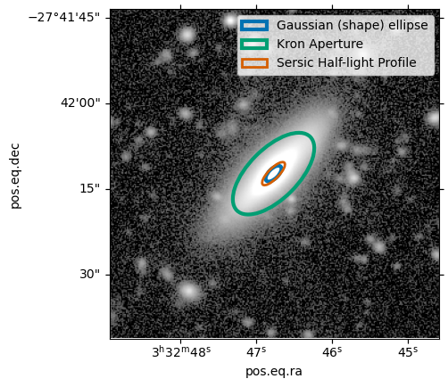

```python
plt.subplot(projection=WCS(cutout.getWcs().getFitsMetadata()))
extent = (cutout.getBBox().beginX, cutout.getBBox().endX,
          cutout.getBBox().beginY, cutout.getBBox().endY)

plt.imshow(cutout.image.array, extent=extent, origin='lower', cmap='gray',
           vmin=0.1, vmax=500, norm='asinh')

gaussell_pix_ellipse = gaussell_ellipse.to_pixel(WCS(cutout.getWcs().getFitsMetadata()))
gaussell_pix_ellipse.plot(color=colors[0], lw=3, label='Gaussian (shape) ellipse')

kron_pix_aperture = kron_aperture.to_pixel(WCS(cutout.getWcs().getFitsMetadata()))
kron_pix_aperture.plot(color=colors[1], lw=3, label='Kron Aperture')

sersic_pix_ellipse = sersic_ellipse.to_pixel(WCS(cutout.getWcs().getFitsMetadata()))
sersic_pix_ellipse.plot(color=colors[2], lw=2, label='Sersic Half-light Profile')
plt.legend()
```

> Figure 1: An i-band image cutout of an example galaxy (grayscale). The Kron aperture used for Kron photometry is overplotted (green), as well as the half-light profile from the 2D Gaussian model (blue) and Sersic model (orange).

## 4. Sersic reconstruction

For some science applications it is useful to compare the on-sky image to the sersic model, for example to assess goodness of fit. The cells below demonstrate how to reconstruct the best-fitting sersic model that produced the `<band>_sersicFlux`, and represents the morphological parameters stored in the `objectTable`.

A straitforward way to do this is using the `galsim`, which is the galaxy simulation package used to build the DP0.2 simulated images. Note that the algorithm used to measure the sersic fluxes, `multiprofit`, is a Gaussian mixture model that approximates a sersic model. Renderings of the galaxy using as a pure sersic model using `galsim` is simpler to plot, but may not be perfectly identical to that built with Gaussian mixture.

It is also good to be aware of objects with Sersic index `n` that are measured to be suspiciously close to 1 (e.g. 1+/- 1e-6). This may happen for poorly fit objects because n=1 is the starting guess, and the optimizer tends to give up if it can't improve within 5-10 iterations.

Below, build the sersic model using the `galsim` function `gs.Sersic` using the sersic parameters from the cell above. Note that the total flux of the model very closely approximates the `sersicFlux` from the `objectTable`, indicating (in this case) a good fit.

```
Total flux of model =  1707512.4 nJy, very close to flux from objectTable =  1707590.0  nJy
```

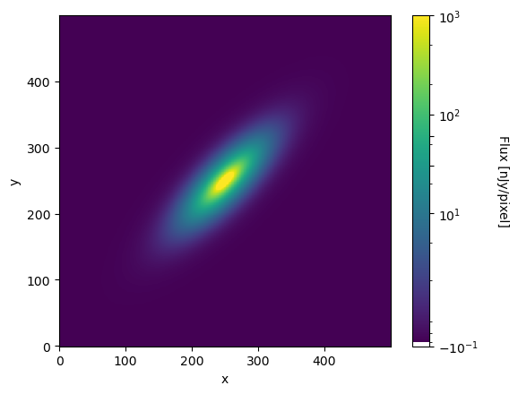

```python
sersic = gs.Sersic(n=tab['sersic_index'][wh][indx], half_light_radius=r_major * np.sqrt(ba),
                   flux=tab['i_sersicFlux'][wh][indx]).shear(q=ba, beta=pa * gs.degrees)

img = sersic.drawImage(nx=500, ny=500, method="real_space", scale=arcsec_per_pix).array

print('Total flux of model = ', np.sum(img), 'nJy, very close to flux from objectTable = ',
      tab['i_sersicFlux'][wh][indx], ' nJy')

fig, ax = plt.subplots()
im = ax.imshow(img, origin='lower', interpolation='nearest', vmin=0, vmax=1000, norm='asinh')
cbar = fig.colorbar(im, ax=ax)
cbar.set_label('Flux [nJy/pixel]', rotation=270, labelpad=25)
cbar.set_ticks([-0.1, 10, 30, 60, 100, 1000])
plt.xlabel('x')
plt.ylabel('y')
plt.show()
```

> Figure 2: The best fit Sersic model of the galaxy in Figure 1 that was used to measure `sersicFlux` of the galaxy.

## 5. Known Issues

### 5.1 BD Models

BD models (where B and D refers to bulge and disk) produce measurements similar to those generated from modeling a single Sersic profile. The models are then integrated to estimate the total flux `<f>_bdFluxB` and `<f>_bdFluxD`. But, rather than using the best fit sersic index obtained from modeling the 6 images in each filter, the BD fluxes are measured from a model with the sersic index n fixed to either 1 (exponential disk in the case of D) or 4 (de Vaucouleurs bulge in the case of B). Note that this is not an equal decomposition of the two component sersic modeling as part of `cModel`.

There are known issues related to these parameters:

1. The units in the DP1 schema are wrong for `<f>_bdReD` and `<f>_bdReB` (where `<f>_` indicates a measurement exists for each of the 6 filters). These are the effective radii measured on each filter image and the units are pixel.
2. The units in the DP1 schema are wrong for ellipticity parameters `<f>_bdE1` and `<f>_bdE2`.
3. A bug currently affects the `objectTable` values for `<f>_bdE1`. In the meantime this parameter should not be used.
4. A note here for clarity: BD model shape parameters are not cataloged in the same way as the metrics for Sersic models. In the future, [galsim.Shear](https://galsim-developers.github.io/GalSim/_build/html/shear.html) can be used to convert the ellipicity parameters`<f>_bdE1` and `<f>_bdE2` to extract the shape parameters, but awaits the bug fix to `<f>_bdE1` before it can be used.

It is currently recommended to not use any BD parameters for science with DP1.

### 5.2 Kron

A known issue for Kron shapes exists.

1. The units in the DP1 schema is wrong for Kron radius. The unit is pixel.